# Titanic_Data_Analysis

This is an analysis of the Titanic survivorship. Main Question: What factors made people more likely to survive?

```python
# First, let's load the dataset downloaded from Kaggle.com
import pandas as pd
import numpy as np
import seaborn as sns
import matplotlib.pyplot as plt
%pylab inline

# load the dataset into a dataframe
titanic_df = pd.read_csv('titanic_data.csv')
# look at the data structure
titanic_df.head()
```

|  | PassengerId | Survived | Pclass | Name | Sex | Age | SibSp | Parch | Ticket | Fare | Cabin | Embarked |
| --- | --- | --- | --- | --- | --- | --- | --- | --- | --- | --- | --- | --- |
| 0 | 1 | 0 | 3 | Braund, Mr. Owen Harris | male | 22 | 1 | 0 | A/5 21171 | 7.2500 | NaN | S |
| 1 | 2 | 1 | 1 | Cumings, Mrs. John Bradley (Florence Briggs Th... | female | 38 | 1 | 0 | PC 17599 | 71.2833 | C85 | C |
| 2 | 3 | 1 | 3 | Heikkinen, Miss. Laina | female | 26 | 0 | 0 | STON/O2. 3101282 | 7.9250 | NaN | S |
| 3 | 4 | 1 | 1 | Futrelle, Mrs. Jacques Heath (Lily May Peel) | female | 35 | 1 | 0 | 113803 | 53.1000 | C123 | S |
| 4 | 5 | 0 | 3 | Allen, Mr. William Henry | male | 35 | 0 | 0 | 373450 | 8.0500 | NaN | S |

```python
# look at the information about the data
titanic_df.describe()
```

|  | PassengerId | Survived | Pclass | Age | SibSp | Parch | Fare |
| --- | --- | --- | --- | --- | --- | --- | --- |
| count | 891.000000 | 891.000000 | 891.000000 | 714.000000 | 891.000000 | 891.000000 | 891.000000 |
| mean | 446.000000 | 0.383838 | 2.308642 | 29.699118 | 0.523008 | 0.381594 | 32.204208 |
| std | 257.353842 | 0.486592 | 0.836071 | 14.526497 | 1.102743 | 0.806057 | 49.693429 |
| min | 1.000000 | 0.000000 | 1.000000 | 0.420000 | 0.000000 | 0.000000 | 0.000000 |
| 25% | 223.500000 | 0.000000 | 2.000000 | 20.125000 | 0.000000 | 0.000000 | 7.910400 |
| 50% | 446.000000 | 0.000000 | 3.000000 | 28.000000 | 0.000000 | 0.000000 | 14.454200 |
| 75% | 668.500000 | 1.000000 | 3.000000 | 38.000000 | 1.000000 | 0.000000 | 31.000000 |
| max | 891.000000 | 1.000000 | 3.000000 | 80.000000 | 8.000000 | 6.000000 | 512.329200 |

From the output above, we can see:

1. There are 891 records in the dataset
2. The mean age of the passengers was about 29. The oldest was 80, the youngest was 0.42. And the overall passenger population were faily young, as 75% of them were under the age of 38.
3. About 38% of the passengers survived.
4. Some columns are missing values. So, let's look at more.

```python
# Find more information about the data
titanic_df.info()
```

```
<class 'pandas.core.frame.DataFrame'>
Int64Index: 891 entries, 0 to 890
Data columns (total 12 columns):
PassengerId    891 non-null int64
Survived       891 non-null int64
Pclass         891 non-null int64
Name           891 non-null object
Sex            891 non-null object
Age            714 non-null float64
SibSp          891 non-null int64
Parch          891 non-null int64
Ticket         891 non-null object
Fare           891 non-null float64
Cabin          204 non-null object
Embarked       889 non-null object
dtypes: float64(2), int64(5), object(5)
memory usage: 90.5+ KB
```

From the output above, we can see:

1. The columns missing are non-numeric, like Name, Sex, Cabin, and we can't calculate the means and std with them.
2. Cabin column has 687 missing values.
3. Age column has 177 missing values.
4. Embarked column has 2 missing values.

Will keep the missing values in mind.

```python
# Since Survived column's values of 0 and 1 may be difficult to communicate to non-technical people.
# Add a new column called HasSurvived with values of yes or no.

# define a function that returns yes to 1, and no to 0
def survivor_yes_no(passenger):
    if passenger.loc['Survived'] == 0:
        return 'no'
    elif passenger.loc['Survived'] == 1:
        return 'yes'
# define a new column called HasSurvived
titanic_df['HasSurvived'] = titanic_df.apply(survivor_yes_no, axis=1)
#let's check out the first 10 rows
titanic_df[0:10]
```

|  | PassengerId | Survived | Pclass | Name | Sex | Age | SibSp | Parch | Ticket | Fare | Cabin | Embarked | HasSurvived |
| --- | --- | --- | --- | --- | --- | --- | --- | --- | --- | --- | --- | --- | --- |
| 0 | 1 | 0 | 3 | Braund, Mr. Owen Harris | male | 22 | 1 | 0 | A/5 21171 | 7.2500 | NaN | S | no |
| 1 | 2 | 1 | 1 | Cumings, Mrs. John Bradley (Florence Briggs Th... | female | 38 | 1 | 0 | PC 17599 | 71.2833 | C85 | C | yes |
| 2 | 3 | 1 | 3 | Heikkinen, Miss. Laina | female | 26 | 0 | 0 | STON/O2. 3101282 | 7.9250 | NaN | S | yes |
| 3 | 4 | 1 | 1 | Futrelle, Mrs. Jacques Heath (Lily May Peel) | female | 35 | 1 | 0 | 113803 | 53.1000 | C123 | S | yes |
| 4 | 5 | 0 | 3 | Allen, Mr. William Henry | male | 35 | 0 | 0 | 373450 | 8.0500 | NaN | S | no |
| 5 | 6 | 0 | 3 | Moran, Mr. James | male | NaN | 0 | 0 | 330877 | 8.4583 | NaN | Q | no |
| 6 | 7 | 0 | 1 | McCarthy, Mr. Timothy J | male | 54 | 0 | 0 | 17463 | 51.8625 | E46 | S | no |
| 7 | 8 | 0 | 3 | Palsson, Master. Gosta Leonard | male | 2 | 3 | 1 | 349909 | 21.0750 | NaN | S | no |
| 8 | 9 | 1 | 3 | Johnson, Mrs. Oscar W (Elisabeth Vilhelmina Berg) | female | 27 | 0 | 2 | 347742 | 11.1333 | NaN | S | yes |
| 9 | 10 | 1 | 2 | Nasser, Mrs. Nicholas (Adele Achem) | female | 14 | 1 | 0 | 237736 | 30.0708 | NaN | C | yes |

Now, let's look at the impact of Sex to the survivorship. Which sex had better chance of survival?

```python
# First, group the data by HasSurvived and Sex
survived_or_not = titanic_df.groupby(['HasSurvived', 'Sex'])
survived_or_not['Sex'].count()
```

```
HasSurvived  Sex
no           female     81
             male      468
yes          female    233
             male      109
Name: Sex, dtype: int64
```

From the output results above, we can tell more females survived.

But, what percentage of females survived vs males?

```python
print titanic_df.groupby('Sex')['Survived'].mean()
```

```
Sex
female    0.742038
male      0.188908
Name: Survived, dtype: float64
```

It looks like females had about 74% of chance of survival vs only 18.9% for males.

```
[]
```

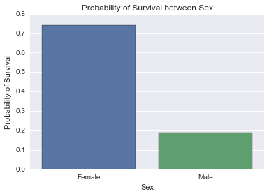

```python
# make a chart about Probablity of Survival by Sex.
p = sns.barplot(data = titanic_df.groupby('Sex', as_index = False)['Survived'].mean(), x = 'Sex', y = 'Survived')
p.set(xlabel = 'Sex', ylabel = 'Probability of Survival', title = 'Probability of Survival between Sex')
p.set_xticklabels(['Female', 'Male'])
p.plot()
```

Analysis on the Probability of Survival between Sex:

Females were much more likely to survive than males: 74% vs 18.9%. This is a significant difference.

Second, let's look at the Age factor. Is there some pattern in the age distribution for the survived vs non-survived?

```python
# Because Age has such a large range in values, let's create a new column called AgeBin to divide the Age into groups

# Create a function to create the bin group
def age_bin(passenger):
    if passenger['Age']> 0 and passenger['Age']<= 10:
        return '0-10'
    elif passenger['Age']>10 and passenger['Age']<= 20:
        return '11-20'
    elif passenger['Age']>20 and passenger['Age']<= 30:
        return '21-30'
    elif passenger['Age']>30 and passenger['Age']<= 40:
        return '31-40'
    elif passenger['Age']>40 and passenger['Age']<= 50:
        return '41-50'
    elif passenger['Age']>50 and passenger['Age']<= 60:
        return '51-60'
    elif passenger['Age']>60 and passenger['Age']<= 70:
        return '61-70'
    elif passenger['Age']>70 and passenger['Age']<= 80:
        return '71-80'

# Create a new column called called AgeBin
titanic_df['AgeBin']= titanic_df.apply(age_bin, axis=1)
# Look at the data
titanic_df.head()
```

|  | PassengerId | Survived | Pclass | Name | Sex | Age | SibSp | Parch | Ticket | Fare | Cabin | Embarked | HasSurvived | AgeBin |
| --- | --- | --- | --- | --- | --- | --- | --- | --- | --- | --- | --- | --- | --- | --- |
| 0 | 1 | 0 | 3 | Braund, Mr. Owen Harris | male | 22 | 1 | 0 | A/5 21171 | 7.2500 | NaN | S | no | 21-30 |
| 1 | 2 | 1 | 1 | Cumings, Mrs. John Bradley (Florence Briggs Th... | female | 38 | 1 | 0 | PC 17599 | 71.2833 | C85 | C | yes | 31-40 |
| 2 | 3 | 1 | 3 | Heikkinen, Miss. Laina | female | 26 | 0 | 0 | STON/O2. 3101282 | 7.9250 | NaN | S | yes | 21-30 |
| 3 | 4 | 1 | 1 | Futrelle, Mrs. Jacques Heath (Lily May Peel) | female | 35 | 1 | 0 | 113803 | 53.1000 | C123 | S | yes | 31-40 |
| 4 | 5 | 0 | 3 | Allen, Mr. William Henry | male | 35 | 0 | 0 | 373450 | 8.0500 | NaN | S | no | 31-40 |

```python
# Now drop the null values
titanic_age_df = titanic_df[['Survived', 'HasSurvived', 'Age', 'AgeBin']].dropna()

#Calculate some statistics on the overall passenger polulation
print titanic_age_df['Age'].mean()
print titanic_age_df['Age'].std()
print titanic_age_df['Age'].max()
print titanic_age_df['Age'].min()
```

```
29.6991176471
14.5264973323
80.0
0.42
```

The results above show: The mean age of all passengers(exclude 177 passengers with missing age values) on the ship was about 29. The oldest was 80, the youngest was 0.42.

Now, what about the age distribution of the survived vs non survived?

```python
#Group the data by whether the passengers survived or not
survived_or_not = titanic_age_df.groupby(['HasSurvived'])

print 'mean: ' + str(survived_or_not.mean()['Age'])
print 'max: ' + str(survived_or_not.max()['Age'])
print 'min: ' + str(survived_or_not.min()['Age'])
print 'std: ' + str(survived_or_not.std()['Age'])
```

```
mean: HasSurvived
no     30.626179
yes    28.343690
Name: Age, dtype: float64
max: HasSurvived
no     74
yes    80
Name: Age, dtype: float64
min: HasSurvived
no     1.00
yes    0.42
Name: Age, dtype: float64
std: HasSurvived
no     14.172110
yes    14.950952
Name: Age, dtype: float64
```

From the results above, it does not seem to have a significant difference/gap between the age distribution of the survived vs not survived.

Now, let's look at the comparison in graphs.

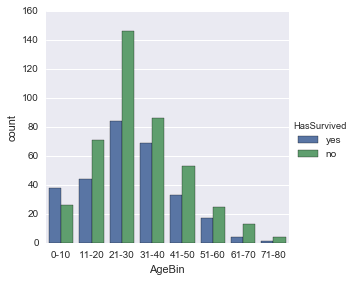

```python
# Make a bar chart to show the age distribution for both the survivors and non-survivors
survived_or_not = titanic_age_df.sort_values(by='AgeBin')
sns.factorplot('AgeBin', data=survived_or_not, hue='HasSurvived', kind='count')
```

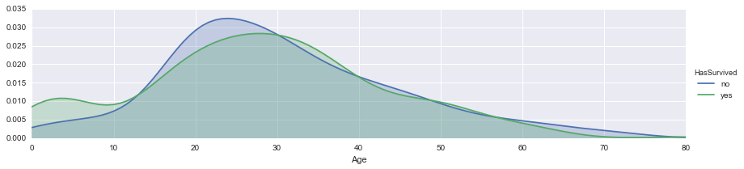

```python
# Make a facetgrid
grid = sns.FacetGrid(titanic_age_df, hue="HasSurvived",aspect=4)
grid.map(sns.kdeplot,'Age',shade= True)
oldest = titanic_age_df['Age'].max()
grid.set(xlim=(0,oldest))
grid.add_legend()
```

From both the bar charts and the facetgrid, we see the similar results. There isn't a big difference in age distribution between the survived vs not survived.

However, there is some noticeable difference:

1. For children <= 10, more survived than not;
2. For youth between 10-30, quite some more died than survived. Especially for those between 20-30.

Now, let's look at the probablity of survival between age groups.

```python
# Calculate the probablity of survival between age groups
print titanic_age_df.groupby('AgeBin')['Survived'].mean()
```

```
AgeBin
0-10     0.593750
11-20    0.382609
21-30    0.365217
31-40    0.445161
41-50    0.383721
51-60    0.404762
61-70    0.235294
71-80    0.200000
Name: Survived, dtype: float64
```

```
[]
```

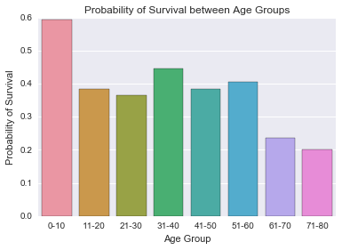

```python
# make a chart about Probablity of Survival by Age Groups.
p = sns.barplot(data = titanic_age_df.groupby('AgeBin', as_index = False)['Survived'].mean(), x = 'AgeBin', y = 'Survived')
p.set(xlabel = 'Age Group', ylabel = 'Probability of Survival', title = 'Probability of Survival between Age Groups')
p.set_xticklabels(['0-10', '11-20', '21-30', '31-40', '41-50', '51-60', '61-70', '71-80'])
p.plot()
```

Analysis on the Probablity of Survival by Age Groups:

1. Passengers younger than 10 had the highest probability of survival: 59%
2. Passengers between 71-80 had the lowest probablity of survival: 20%

Now, let's look at the probability of survival by Gender and Age Group.

```
[]
```

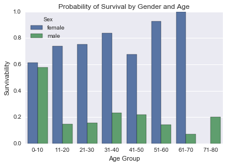

```python
# Use the original dataset without dropping the null age values, as I want to use all data on Sex.
# there isn't missing value in Sex

p = sns.barplot(data=titanic_df.groupby(['AgeBin', 'Sex'], as_index=False)['Survived'].mean(), x='AgeBin', y='Survived',
                hue='Sex')
p.set(ylabel='Survivability', xlabel='Age Group', title = 'Probability of Survival by Gender and Age')
p.plot()
```

Analysis on the Probability of Survival by Gender and Age:

1. In every age group, females had higher probablity of survival.
2. In age group of 71-80, there were only males. This may also explain why this age group had the lowest probablity of survival: 20%

Third, let's see the Pclass factor. Which class of passengers were more likely to survive?

```python
#Group data by Pclass
titanic_class_df = titanic_df.groupby(['HasSurvived', 'Pclass'])
titanic_class_df['Pclass'].count()
```

```
HasSurvived  Pclass
no           1          80
             2          97
             3         372
yes          1         136
             2          87
             3         119
Name: Pclass, dtype: int64
```

From the results above, it seems that more 1st class passengers survived.

Now, let's look at the probablity of survival by Pclass.

```python
# calculate the probablity of survival by Pclass
titanic_df.groupby('Pclass')['Survived'].mean()
```

```
Pclass
1    0.629630
2    0.472826
3    0.242363
Name: Survived, dtype: float64
```

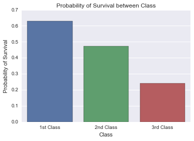

```python
# make a graph of Probablity of Survival by Pclass
p = sns.barplot(data = titanic_df.groupby('Pclass', as_index = False)['Survived'].mean(), x = 'Pclass', y = 'Survived')
p.set(xlabel='Class', ylabel='Probability of Survival', title = 'Probability of Survival between Class')
p.set_xticklabels(['1st Class', '2nd Class', '3rd Class'])
```

Analysis on the Probability of Survival between Class:

1. 1st class passengers had highest chance of survival: 63%
2. 3rd class passengers had lowest chance of survival: < 25%
3. 2nd class passengers had close to 50% of chance of survival.

Now, what about Probablity of Survival by Pclass and Age Group?

```
[]
```

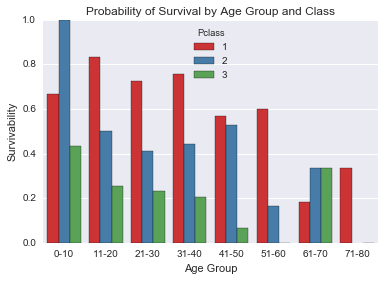

```python
# make a chart of Probablity of Survival by Pclass and Age Group. Again, I will use all the data, not dropping the null Age values.
p= sns.barplot(data=titanic_df.groupby(['AgeBin', 'Pclass'], as_index=False)['Survived'].mean(), x='AgeBin', y='Survived',
               hue='Pclass', palette='Set1')
p.set(ylabel = 'Survivability', xlabel='Age Group', title = 'Probability of Survival by Age Group and Class')
p.plot()
```

Fourth, let's look at the family factor. Did having family increase the odds of survival?

```python
# First, let's add a column called HasFamily. Those who had siblings/spouses, or parents/children will be counted as HasFamily.

def has_family(passenger):
    if passenger['SibSp']> 0 or passenger['Parch'] > 0:
        return 'yes'
    else:
        return 'no'

titanic_df['HasFamily'] = titanic_df.apply(has_family, axis='columns')
titanic_df[0:10]
```

|  | PassengerId | Survived | Pclass | Name | Sex | Age | SibSp | Parch | Ticket | Fare | Cabin | Embarked | HasSurvived | AgeBin | HasFamily |
| --- | --- | --- | --- | --- | --- | --- | --- | --- | --- | --- | --- | --- | --- | --- | --- |
| 0 | 1 | 0 | 3 | Braund, Mr. Owen Harris | male | 22 | 1 | 0 | A/5 21171 | 7.2500 | NaN | S | no | 21-30 | yes |
| 1 | 2 | 1 | 1 | Cumings, Mrs. John Bradley (Florence Briggs Th... | female | 38 | 1 | 0 | PC 17599 | 71.2833 | C85 | C | yes | 31-40 | yes |
| 2 | 3 | 1 | 3 | Heikkinen, Miss. Laina | female | 26 | 0 | 0 | STON/O2. 3101282 | 7.9250 | NaN | S | yes | 21-30 | no |
| 3 | 4 | 1 | 1 | Futrelle, Mrs. Jacques Heath (Lily May Peel) | female | 35 | 1 | 0 | 113803 | 53.1000 | C123 | S | yes | 31-40 | yes |
| 4 | 5 | 0 | 3 | Allen, Mr. William Henry | male | 35 | 0 | 0 | 373450 | 8.0500 | NaN | S | no | 31-40 | no |
| 5 | 6 | 0 | 3 | Moran, Mr. James | male | NaN | 0 | 0 | 330877 | 8.4583 | NaN | Q | no | None | no |
| 6 | 7 | 0 | 1 | McCarthy, Mr. Timothy J | male | 54 | 0 | 0 | 17463 | 51.8625 | E46 | S | no | 51-60 | no |
| 7 | 8 | 0 | 3 | Palsson, Master. Gosta Leonard | male | 2 | 3 | 1 | 349909 | 21.0750 | NaN | S | no | 0-10 | yes |
| 8 | 9 | 1 | 3 | Johnson, Mrs. Oscar W (Elisabeth Vilhelmina Berg) | female | 27 | 0 | 2 | 347742 | 11.1333 | NaN | S | yes | 21-30 | yes |
| 9 | 10 | 1 | 2 | Nasser, Mrs. Nicholas (Adele Achem) | female | 14 | 1 | 0 | 237736 | 30.0708 | NaN | C | yes | 11-20 | yes |

```python
#Group data by HasFamily
titanic_family_df = titanic_df.groupby(['HasSurvived', 'HasFamily'])
titanic_family_df['HasFamily'].count()
```

```
HasSurvived  HasFamily
no           no           374
             yes          175
yes          no           163
             yes          179
Name: HasFamily, dtype: int64
```

Analysis: 1.The amount of the passengers with family survived vs those without family do not have a big gap: 163 vs 179. 2.However, a lot less passengers with family died vs those without family: 175 vs 374 However, let's look at the probability of survival by HasFamily as well.

```python
# Calculating the probability of survival by HasFamily
titanic_df.groupby('HasFamily')['Survived'].mean()
```

```
HasFamily
no     0.303538
yes    0.505650
Name: Survived, dtype: float64
```

```
[]
```

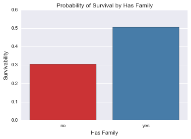

```python
# Make a chart of the probability of survival by HasFamily
p= sns.barplot(data=titanic_df.groupby(['HasFamily'], as_index=False)['Survived'].mean(), x='HasFamily', y='Survived',
               palette='Set1')
p.set(ylabel = 'Survivability', xlabel='Has Family', title = 'Probability of Survival by Has Family')
p.plot()
```

Analysis on the Probability of Survival by Has Family: It looks like having family increased the chance of survival by about 20%.

Now, what about Probablity of Survival by Pclass and HasFamily.

```
[]
```

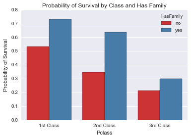

```python
# make a chart of about Probablity of Survival by Pclass and HasFamily
p = sns.barplot(data = titanic_df.groupby(['Pclass', 'HasFamily'], as_index = False)['Survived'].mean(), x = 'Pclass',
                y = 'Survived', hue = 'HasFamily',  palette='Set1' )
p.set(xlabel = 'Pclass', ylabel = 'Probability of Survival', title = 'Probability of Survival by Class and Has Family')
p.set_xticklabels(['1st Class', '2nd Class', '3rd Class'])
p.plot()
```

Analysis on the Probability of Survival by Class and Has Family: Among all classes, those passengers with family had a better chance of survival. No surprise.

Fifth, let's look at Fare.

```python
# First look at the Fare values:
titanic_df['Fare'].describe()
```

```
count    891.000000
mean      32.204208
std       49.693429
min        0.000000
25%        7.910400
50%       14.454200
75%       31.000000
max      512.329200
Name: Fare, dtype: float64
```

Analysis:

1. The mean fare price was about 32.
2. 75% of fare prices fell under 31.
3. Some passengers didn't pay for the fare. The min price was 0.
4. The max price was about 512.

```python
# I want to break Fare into different Price bins.
# Because 75% of the fares are < 31, I will set the bins accordingly.

def fare_bin(passenger):
    if passenger['Fare']<= 31.0:
        return '0-31'
    elif passenger['Fare']<= 100.0:
        return '32-100'
    if passenger['Fare']<= 200.0:
        return '101-200'
    if passenger['Fare']<= 513.0:
        return '201-513'

# Add a FareBin to the dataframe
titanic_df['Fare Price'] = titanic_df.apply(fare_bin, axis=1)
#look at the new column
titanic_df[0:5]
```

|  | PassengerId | Survived | Pclass | Name | Sex | Age | SibSp | Parch | Ticket | Fare | Cabin | Embarked | HasSurvived | AgeBin | HasFamily | Fare Price |
| --- | --- | --- | --- | --- | --- | --- | --- | --- | --- | --- | --- | --- | --- | --- | --- | --- |
| 0 | 1 | 0 | 3 | Braund, Mr. Owen Harris | male | 22 | 1 | 0 | A/5 21171 | 7.2500 | NaN | S | no | 21-30 | yes | 0-31 |
| 1 | 2 | 1 | 1 | Cumings, Mrs. John Bradley (Florence Briggs Th... | female | 38 | 1 | 0 | PC 17599 | 71.2833 | C85 | C | yes | 31-40 | yes | 32-100 |
| 2 | 3 | 1 | 3 | Heikkinen, Miss. Laina | female | 26 | 0 | 0 | STON/O2. 3101282 | 7.9250 | NaN | S | yes | 21-30 | no | 0-31 |
| 3 | 4 | 1 | 1 | Futrelle, Mrs. Jacques Heath (Lily May Peel) | female | 35 | 1 | 0 | 113803 | 53.1000 | C123 | S | yes | 31-40 | yes | 32-100 |
| 4 | 5 | 0 | 3 | Allen, Mr. William Henry | male | 35 | 0 | 0 | 373450 | 8.0500 | NaN | S | no | 31-40 | no | 0-31 |

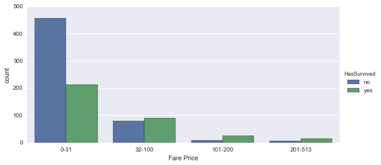

```python
# Make a bar chart to show the age distribution for both the survivors and non-survivors
survived_or_not = titanic_df.sort_values(by='Fare Price')
sns.factorplot('Fare Price', data=titanic_df, hue='HasSurvived', kind='count', aspect=2,
              x_order=['0-31', '32-100','101-200','201-513'])
```

Analysis: The price range 0-31 had the most fares.

Now, how about the probability of survival by Fare Price?

```python
# Calculating the probability of survival by Fare Price
titanic_df.groupby('Fare Price')['Survived'].mean()
```

```
Fare Price
0-31       0.318386
101-200    0.757576
201-513    0.700000
32-100     0.532544
Name: Survived, dtype: float64
```

```
[]
```

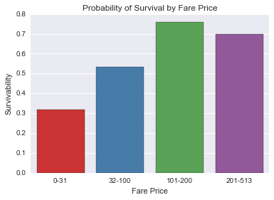

```python
# Make a chart of the probability of survival by Fare Price
p= sns.barplot(data=titanic_df.groupby(['Fare Price'], as_index=False)['Survived'].mean(), x='Fare Price', y='Survived',
               palette='Set1', x_order=['0-31', '32-100','101-200','201-513'])
p.set(ylabel = 'Survivability', xlabel='Fare Price', title = 'Probability of Survival by Fare Price')
p.plot()
```

Analysis on the Probability of Survival by Fare Price: 1.The passengers with the lowest price fares(price range 0-31), had the worst chance of survival: 31.8% 2.The passengers with the mid price fares(price range 31-100), had a better chance of survival: 53.2% 3.The passengers with the higher price fares(price range 101-200), had the best chance of survival: 75% 4.The passengers with the highest price fares(price range 201-513), had a good chance of survival: 70%

Let's make a chart of about Probablity of Survival Fare Price and Class

```
[]
```

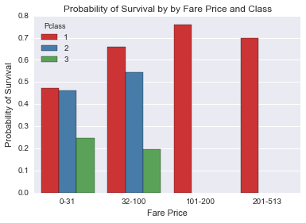

```python
# make a chart of about Probablity of Survival by Pclass and HasFamily
p = sns.barplot(data = titanic_df.groupby(['Fare Price', 'Pclass'], as_index = False)['Survived'].mean(), x = 'Fare Price',
                y = 'Survived', hue = 'Pclass',  palette='Set1', x_order=['0-31', '32-100','101-200','201-513'] )
p.set(xlabel = 'Fare Price', ylabel = 'Probability of Survival', title = 'Probability of Survival by by Fare Price and Class')
p.plot()
```

Analysis on the Probability of Survival by by Fare Price and Class:

From the chart above, we see:

1. Among all fare price ranges, 1st class passengers had the highest chance of survival.
2. 3rd class passengers among the available price ranges had the lowest chance of survival.

Also, was there any non-paid passengers? (fare price=0) How was their survival rate?

```python
#Filter the dataset: leaving only those didn't pay or got a free ride for whatever reason
titanic_non_paid= titanic_df.loc[titanic_df['Fare'] == 0]
survived_or_not=titanic_non_paid.groupby(['HasSurvived', 'Fare'])
survived_or_not['Fare'].count()
```

```
HasSurvived  Fare
no           0       14
yes          0        1
Name: Fare, dtype: int64
```

Analysis: It seems all the free-riders died except one. This is interesting.

Last, let's look at the Embarked variable.

```python
#There are two missing values in Embarked column. I decide not to drop it, as 2 out of 891 is not significant.
titanic_class_df = titanic_df.groupby(['HasSurvived', 'Embarked'])
titanic_class_df['Embarked'].count()
```

```
HasSurvived  Embarked
no           C            75
             Q            47
             S           427
yes          C            93
             Q            30
             S           217
Name: Embarked, dtype: int64
```

```python
# define a function to convert abbreviation to full name of the embarkation
def convert_embarked(passenger):
    if passenger['Embarked']== 'C':
        return 'Cherbourg'
    elif passenger['Embarked']== 'Q':
        return 'Queenstown'
    elif passenger['Embarked']== 'S':
        return 'Southampton'
# Add a new column called Embarked At
titanic_df['Embarked at'] = titanic_df.apply(convert_embarked, axis=1)
titanic_df[0:5]
```

|  | PassengerId | Survived | Pclass | Name | Sex | Age | SibSp | Parch | Ticket | Fare | Cabin | Embarked | HasSurvived | AgeBin | HasFamily | Fare Price | Embarked at |
| --- | --- | --- | --- | --- | --- | --- | --- | --- | --- | --- | --- | --- | --- | --- | --- | --- | --- |
| 0 | 1 | 0 | 3 | Braund, Mr. Owen Harris | male | 22 | 1 | 0 | A/5 21171 | 7.2500 | NaN | S | no | 21-30 | yes | 0-31 | Southampton |
| 1 | 2 | 1 | 1 | Cumings, Mrs. John Bradley (Florence Briggs Th... | female | 38 | 1 | 0 | PC 17599 | 71.2833 | C85 | C | yes | 31-40 | yes | 32-100 | Cherbourg |
| 2 | 3 | 1 | 3 | Heikkinen, Miss. Laina | female | 26 | 0 | 0 | STON/O2. 3101282 | 7.9250 | NaN | S | yes | 21-30 | no | 0-31 | Southampton |
| 3 | 4 | 1 | 1 | Futrelle, Mrs. Jacques Heath (Lily May Peel) | female | 35 | 1 | 0 | 113803 | 53.1000 | C123 | S | yes | 31-40 | yes | 32-100 | Southampton |
| 4 | 5 | 0 | 3 | Allen, Mr. William Henry | male | 35 | 0 | 0 | 373450 | 8.0500 | NaN | S | no | 31-40 | no | 0-31 | Southampton |

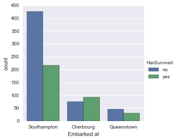

```python
# make a chart
sns.factorplot('Embarked at', data=titanic_df, hue='HasSurvived', kind='count')
```

Analysis: It looks like most passengers were embarked at Southampton.

Let's look at the probablity of survival by Embarked

```python
# calculate the probablity of survival by Embarked at
titanic_df.groupby('Embarked at')['Survived'].mean()
```

```
Embarked at
Cherbourg      0.553571
Queenstown     0.389610
Southampton    0.336957
Name: Survived, dtype: float64
```

```
[]
```

[figure not shown]

```python
# make a graph of Probablity of Survival by Embarked at
p = sns.barplot(data = titanic_df.groupby('Embarked at', as_index = False)['Survived'].mean(), x = 'Embarked at', y = 'Survived')
p.set(xlabel='Embarked at', ylabel='Probability of Survival', title = 'Probability of Survival between Port of Embarkation')
p.plot()
```

Analysis on the Probability of Survival between Port of Embarkation 1.Passengers embarked at Cherbourg had the highest chance of survival: 55% 2.Passengers embarked at Queenstown had the lower chance of survival: 39% 3.Passengers embarked at Southhampton had the lower chance of survival: 34%

What about Probablity of Survival by Embarked at and Pclass?

```
[]
```

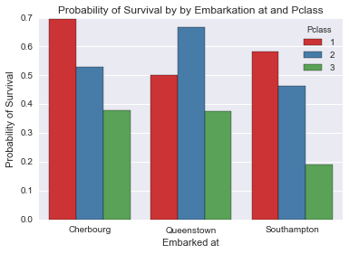

```python
# make a chart of about Probablity of Survival by Embarked at and Pclass
p = sns.barplot(data = titanic_df.groupby(['Embarked at', 'Pclass'], as_index = False)['Survived'].mean(), x = 'Embarked at',
                y = 'Survived', hue = 'Pclass',  palette='Set1' )
p.set(xlabel = 'Embarked at', ylabel = 'Probability of Survival', title = 'Probability of Survival by by Embarkation at and Pclass')
p.plot()
```

Analysis for Probablity of Survival by Embarked at and Pclass:

1. Passengers embarked at Cherbourg and Southampton had the same pattern of survival rate by Pclass: 1st class had the highest, then 2nd class, then 3rd class.
2. For assengers from Queenstown, the 2nd class passengers had the highest survival rate.

```python
titanic_df.corr()
```

|  | PassengerId | Survived | Pclass | Age | SibSp | Parch | Fare |
| --- | --- | --- | --- | --- | --- | --- | --- |
| PassengerId | 1.000000 | -0.005007 | -0.035144 | 0.036847 | -0.057527 | -0.001652 | 0.012658 |
| Survived | -0.005007 | 1.000000 | -0.338481 | -0.077221 | -0.035322 | 0.081629 | 0.257307 |
| Pclass | -0.035144 | -0.338481 | 1.000000 | -0.369226 | 0.083081 | 0.018443 | -0.549500 |
| Age | 0.036847 | -0.077221 | -0.369226 | 1.000000 | -0.308247 | -0.189119 | 0.096067 |
| SibSp | -0.057527 | -0.035322 | 0.083081 | -0.308247 | 1.000000 | 0.414838 | 0.159651 |
| Parch | -0.001652 | 0.081629 | 0.018443 | -0.189119 | 0.414838 | 1.000000 | 0.216225 |
| Fare | 0.012658 | 0.257307 | -0.549500 | 0.096067 | 0.159651 | 0.216225 | 1.000000 |

I see that Pclass has the strongest negative correlation with survivorship: -0.338481. It means the higher the class number was (which means the "the lower the class"), the less likely the passenger was going to survice.

Age also has a negative correlation with with survivorship, but not as strong: -0.077221. So, the older the passenger was, the lessly likely he/she was going to survive.

Limitation of the analysis:

1. Age column has 177 values missing out of 891 records. The missing values may impact the age distribution of the survivalship. I chose to drop the missing age values when computing the analysis, as I didn't want to fill them with 0s. 0 in the place of missing age could skew the age distribution to the younger group.
2. Embarked column also has 2 missing values. I ddin't drop these 2. Because Embarked is a catogorical variable, and I didn't think 2 out of 891 missing would make a big impact.
3. According to Wikipedia, Titanic had around 1317 passengers (actually, the exact number of passengers are unknown), and the dataset used in this analysis only has 891 passengers. So this is a sampe out of the population. My analysis didn't include statistical testing. The conclusion was based on more of my own observations, and not statistically significant.
4. Other varibles not included in this dataset could have been useful in the analysis, such as: the ability to swim, race/ethnic group, profession, etc.